# My R Markdown Primer

Valerie Dominguez

2026-11-13

## R Markdown

R Markdown is a file format for making dynamic documents with R. An R Markdown document is written in markdown (an easy-to-write plain text format) and contains chunks of embedded R code.

## Exploring the Data

For this example, I will use the built-in `mtcars` dataset in R. This dataset contains information about different cars, including their fuel efficiency, horsepower, and weight. I want to explore the relationship between a car’s weight and its miles per gallon (MPG).

## Loading and Summarizing the Dataset

The following code loads the dataset and calculates basic summary statistics.

```r
data(mtcars)

head(mtcars)
```

```
##                    mpg cyl disp  hp drat    wt  qsec vs am gear carb
## Mazda RX4         21.0   6  160 110 3.90 2.620 16.46  0  1    4    4
## Mazda RX4 Wag     21.0   6  160 110 3.90 2.875 17.02  0  1    4    4
## Datsun 710        22.8   4  108  93 3.85 2.320 18.61  1  1    4    1
## Hornet 4 Drive    21.4   6  258 110 3.08 3.215 19.44  1  0    3    1
## Hornet Sportabout 18.7   8  360 175 3.15 3.440 17.02  0  0    3    2
## Valiant           18.1   6  225 105 2.76 3.460 20.22  1  0    3    1
```

```r
summary(mtcars$mpg)
```

```
##    Min. 1st Qu.  Median    Mean 3rd Qu.    Max.
##   10.40   15.43   19.20   20.09   22.80   33.90
```

```r
mean(mtcars$mpg)
```

```
## [1] 20.09062
```

## Mathematical Expression

The mean is calculated by adding all observations and dividing by the total number of observations.

The formula for the mean is:

$$\bar{x} = \frac{\sum_{i=1}^{n} x_i}{n}$$

In this equation, $\bar{x}$ represents the mean, $x_i$ represents each observation, and $n$ represents the number of observations.

Another example of an inline mathematical expression is $\alpha + \beta = \gamma$.

## Data Visualization

Next, I will create a scatterplot using `ggplot2` to explore the relationship between vehicle weight and fuel efficiency.

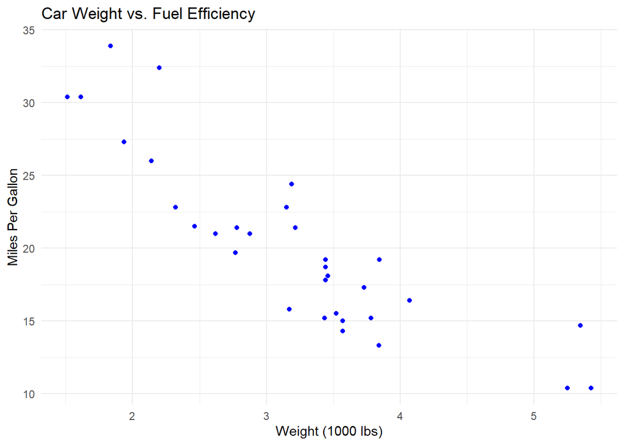

## Analysis

Based on the scatterplot, there appears to be a negative relationship between vehicle weight and fuel efficiency. As the weight of a car increases, its miles per gallon generally decreases. This suggests that heavier cars tend to use more fuel than lighter cars.

## Reflection

Using R Markdown is different from writing a regular report because I can combine my explanations, code, and results in one place. Instead of copying graphs and statistics into a separate document, R Markdown allows me to generate everything together. I also like that I can make changes to my code and update the report by knitting it again. Although learning the formatting takes some practice, I think R Markdown is useful for organizing data analysis projects and making reports more reproducible.